# Numpy array

What are NumPy Arrays?

- NumPy (short for Numerical Python) is a powerful library in Python that provides support for large, multi-dimensional arrays and matrices, along with a large collection of high-level mathematical functions to operate on these arrays efficiently. A NumPy array is the core data structure of the NumPy library.
- Think of a NumPy array as a grid of values, all of the same type, organized in one or more dimensions. This homogeneity is a key difference from Python lists, which can hold items of different types. This uniformity allows NumPy to perform operations much faster.

Key Characteristics of NumPy Arrays:

- Homogeneous: All elements in a NumPy array must be of the same data type (e.g., all integers, all floating-point numbers). This makes operations more efficient.
- Multi-dimensional: NumPy arrays can have one dimension (like a list), two dimensions (like a table or a matrix), or even more dimensions (for representing higher-dimensional data).
- Fixed Size (at creation): While you can reshape arrays, the total number of elements is usually fixed when you create the array.
- Efficient Numerical Operations: NumPy is highly optimized for mathematical and logical operations on entire arrays. This is done using vectorized operations, which are much faster than iterating through Python lists.
- Memory Efficient: Due to the homogeneous nature and optimized storage, NumPy arrays can be more memory-efficient than Python lists for large numerical datasets.
- Foundation for Scientific Computing: NumPy arrays are the fundamental data structure used by many other scientific and data analysis libraries in Python, such as Pandas, SciPy, and scikit-learn.

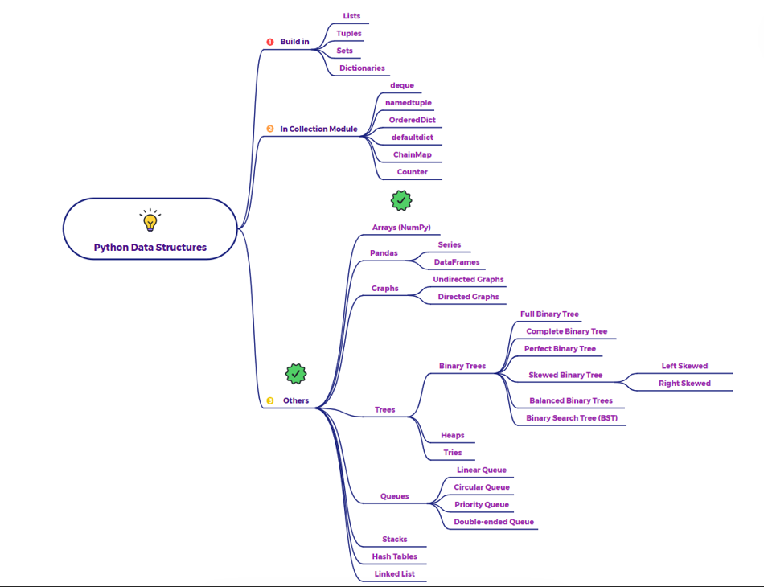

# 1. Define a Utility function to print highlighted characteristics

```python
import numpy as np
import sys # For demonstrating memory efficiency (conceptually)

def highlight_characteristic(name, description, symbol='='):
    """Helper function to print highlighted characteristics."""
    print(f"\n{symbol*5} {name.upper()} {symbol*5}")
    print(description)
    print(f"{symbol*5} {name.upper()} {symbol*5}\n")

print("--- Python NumPy Arrays: Sensor Data Processing Example ---")
```

```
--- Python NumPy Arrays: Sensor Data Processing Example ---
```

```python
# --- Scenario Setup: Simulating Sensor Readings ---
# Imagine 3 sensors taking 5 temperature readings each (e.g., hourly)
sensor_data_2d = np.array([
    [22.5, 23.1, 22.8, 23.0, 22.7],  # Sensor 1: Temperatures
    [21.9, 22.3, 22.0, 22.5, 22.1],  # Sensor 2: Temperatures
    [23.0, 23.5, 23.2, 23.8, 23.3]   # Sensor 3: Temperatures
])
print(f"Original 2D Sensor Data Array (Temperatures):\n{sensor_data_2d}\n")
```

```
Original 2D Sensor Data Array (Temperatures):
[[22.5 23.1 22.8 23.  22.7]
 [21.9 22.3 22.  22.5 22.1]
 [23.  23.5 23.2 23.8 23.3]]
```

# 2. Homogeneous:

- sensor_data_2d is initialized with float values, and its dtype is confirmed as float64.
- The mixed_data example shows that when an array is created with mixed types (int and float), NumPy automatically "upcasts" all elements to the common, most general type (float in this case).
- Similarly, if strings are introduced, all elements are converted to a string data type.

```python
# 1. Homogeneous Characteristic

highlight_characteristic(
    "Homogeneous",
    "All elements in a NumPy array must be of the same data type. If different types are provided, NumPy will automatically upcast to a common, compatible type (e.g., integer to float if floats are present)."
)

print(f"Data type (dtype) of sensor_data_2d: {sensor_data_2d.dtype}") # Will be float64 by default

# Example of type casting/upcasting
mixed_data = np.array([1, 2, 3.5, 4]) # Contains int and float
print(f"Mixed data array: {mixed_data}")
print(f"Data type of mixed_data (upcasted to float): {mixed_data.dtype}")

string_data = np.array([1, 2, 'hello', 4]) # Contains int and string
print(f"String data array (upcasted to string): {string_data}")
print(f"Data type of string_data: {string_data.dtype}\n")
```

```
===== HOMOGENEOUS =====
All elements in a NumPy array must be of the same data type. If different types are provided, NumPy will automatically upcast to a common, compatible type (e.g., integer to float if floats are present).
===== HOMOGENEOUS =====

Data type (dtype) of sensor_data_2d: float64
Mixed data array: [1.  2.  3.5 4. ]
Data type of mixed_data (upcasted to float): float64
String data array (upcasted to string): ['1' '2' 'hello' '4']
Data type of string_data: <U21
```

# 3. Multi-dimensional:

- Examples of 1D (single_sensor_readings), 2D (sensor_data_2d), and 3D (environmental_data_3d) arrays are shown.
- The shape attribute explicitly shows the dimensions of the array (e.g., (3, 5) for a 3x5 matrix).
- The ndim attribute confirms the number of dimensions.

```python
# 2. Multi-dimensional Characteristic

highlight_characteristic(
    "Multi-dimensional",
    "NumPy arrays can represent data in one, two, three, or even higher dimensions. They are the fundamental data structure for vectors, matrices, and tensors."
)

# 1D Array (Vector) - e.g., a single sensor's readings
single_sensor_readings = np.array([22.5, 23.1, 22.8, 23.0, 22.7])
print(f"1D Array (Vector):\n{single_sensor_readings}")
print(f"  Shape: {single_sensor_readings.shape} (5 elements)")
print(f"  Dimensions (ndim): {single_sensor_readings.ndim}\n")

# 2D Array (Matrix) - our main sensor_data_2d
print(f"2D Array (Matrix - Sensor Data):\n{sensor_data_2d}")
print(f"  Shape: {sensor_data_2d.shape} (3 rows, 5 columns)")
print(f"  Dimensions (ndim): {sensor_data_2d.ndim}\n")

# 3D Array (Tensor) - e.g., temperature, humidity, pressure readings over time for sensors
environmental_data_3d = np.array([
    [ # Location 1
        [22.5, 60.1, 1012.5], # Sensor 1, Time 1 (Temp, Hum, Pres)
        [23.1, 62.0, 1011.8]  # Sensor 1, Time 2
    ],
    [ # Location 2
        [21.9, 58.5, 1013.0], # Sensor 2, Time 1
        [22.3, 59.8, 1012.7]  # Sensor 2, Time 2
    ]
])
print(f"3D Array (Tensor - Environmental Data):\n{environmental_data_3d}")
print(f"  Shape: {environmental_data_3d.shape} (2 locations, 2 times, 3 metrics)")
print(f"  Dimensions (ndim): {environmental_data_3d.ndim}\n")
```

```
===== MULTI-DIMENSIONAL =====
NumPy arrays can represent data in one, two, three, or even higher dimensions. They are the fundamental data structure for vectors, matrices, and tensors.
===== MULTI-DIMENSIONAL =====

1D Array (Vector):
[22.5 23.1 22.8 23.  22.7]
  Shape: (5,) (5 elements)
  Dimensions (ndim): 1

2D Array (Matrix - Sensor Data):
[[22.5 23.1 22.8 23.  22.7]
 [21.9 22.3 22.  22.5 22.1]
 [23.  23.5 23.2 23.8 23.3]]
  Shape: (3, 5) (3 rows, 5 columns)
  Dimensions (ndim): 2

3D Array (Tensor - Environmental Data):
[[[  22.5   60.1 1012.5]
  [  23.1   62.  1011.8]]

 [[  21.9   58.5 1013. ]
  [  22.3   59.8 1012.7]]]
  Shape: (2, 2, 3) (2 locations, 2 times, 3 metrics)
  Dimensions (ndim): 3
```

# 4. Fixed Size (at creation):

- The np.append() function is demonstrated. It does not modify the original sensor_data_2d array in place; instead, it returns a new array with the appended data.
- Similarly, reshape() returns a new view or copy, leaving the original array's dimensions untouched. This highlights that arrays' sizes are fixed once memory is allocated for them.

```python
# 3. Fixed Size (at creation) Characteristic

highlight_characteristic(
    "Fixed Size (at creation)",
    "Once a NumPy array is created, its size (number of elements and dimensions) is fixed. Operations that seem to change size (like reshaping) actually return a new view or a new array without modifying the original data's memory footprint or creating new data."
)

print(f"Original sensor_data_2d shape: {sensor_data_2d.shape}")
print(f"Original sensor_data_2d data:\n{sensor_data_2d}")

# Attempt to append (this creates a *new* array)
new_reading = np.array([24.0, 24.1, 24.2, 24.3, 24.4])
# np.append returns a new array, doesn't modify in place
appended_array = np.append(sensor_data_2d, [new_reading], axis=0)
print(f"\nResult of np.append (new array created):\n{appended_array}")
print(f"Original sensor_data_2d remains unchanged:\n{sensor_data_2d}")

# Attempt to resize (also creates a new array if elements are added/removed)
# If new size is smaller, it truncates; if larger, it fills with zeros/garbage.
# reshape() creates a view without copying data if possible.
reshaped_array = sensor_data_2d.reshape(5, 3) # Creates a new view if possible
print(f"\nReshaped sensor_data_2d (new view/array):\n{reshaped_array}")
print(f"Original sensor_data_2d remains unchanged:\n{sensor_data_2d}\n")
```

```
===== FIXED SIZE (AT CREATION) =====
Once a NumPy array is created, its size (number of elements and dimensions) is fixed. Operations that seem to change size (like reshaping) actually return a new view or a new array without modifying the original data's memory footprint or creating new data.
===== FIXED SIZE (AT CREATION) =====

Original sensor_data_2d shape: (3, 5)
Original sensor_data_2d data:
[[22.5 23.1 22.8 23.  22.7]
 [21.9 22.3 22.  22.5 22.1]
 [23.  23.5 23.2 23.8 23.3]]

Result of np.append (new array created):
[[22.5 23.1 22.8 23.  22.7]
 [21.9 22.3 22.  22.5 22.1]
 [23.  23.5 23.2 23.8 23.3]
 [24.  24.1 24.2 24.3 24.4]]
Original sensor_data_2d remains unchanged:
[[22.5 23.1 22.8 23.  22.7]
 [21.9 22.3 22.  22.5 22.1]
 [23.  23.5 23.2 23.8 23.3]]

Reshaped sensor_data_2d (new view/array):
[[22.5 23.1 22.8]
 [23.  22.7 21.9]
 [22.3 22.  22.5]
 [22.1 23.  23.5]
 [23.2 23.8 23.3]]
Original sensor_data_2d remains unchanged:
[[22.5 23.1 22.8 23.  22.7]
 [21.9 22.3 22.  22.5 22.1]
 [23.  23.5 23.2 23.8 23.3]]
```

# 5. Memory efficient

When you run this updated code, especially for num_elements = 100000 (or more), you'll see a dramatic difference:

- The Python list will consume significantly more memory because of the overhead of each individual Python object.
- The NumPy array will remain very compact, directly proportional to number_of_elements * size_of_each_element_in_bytes.

```python
# 4. Memory Efficient Characteristic

num_elements = 100000 # Let's use 100,000 elements

# Python List
list_of_numbers_large = list(range(num_elements))
# To get a more accurate total memory for a list, sum the size of the list object and all its elements
total_list_mem = sys.getsizeof(list_of_numbers_large) + sum(sys.getsizeof(i) for i in list_of_numbers_large)
print(f"Total memory size of a Python list of {num_elements} integers: {total_list_mem} bytes")

# NumPy Array
# Let's explicitly define dtype for clarity, e.g., 32-bit integers
numpy_array_of_numbers_large = np.arange(num_elements, dtype=np.int32)
print(f"Memory size of a NumPy array of {num_elements} 32-bit integers: {sys.getsizeof(numpy_array_of_numbers_large)} bytes")

# Also compare with float64, which is common in scientific computing
numpy_array_of_floats_large = np.arange(num_elements, dtype=np.float64)
print(f"Memory size of a NumPy array of {num_elements} 64-bit floats: {sys.getsizeof(numpy_array_of_floats_large)} bytes")

# For comparison, a Python list of 100,000 floats
list_of_floats_large = [float(i) for i in range(num_elements)]
total_list_floats_mem = sys.getsizeof(list_of_floats_large) + sum(sys.getsizeof(i) for i in list_of_floats_large)
print(f"Total memory size of a Python list of {num_elements} floats: {total_list_floats_mem} bytes")
```

```
Total memory size of a Python list of 100000 integers: 3600056 bytes
Memory size of a NumPy array of 100000 32-bit integers: 400112 bytes
Memory size of a NumPy array of 100000 64-bit floats: 800112 bytes
Total memory size of a Python list of 100000 floats: 3200984 bytes
```

# 6. Foundation for Scientific Computing:

```python
# 5. Foundation for Scientific Computing Characteristic

highlight_characteristic(
    "Foundation for Scientific Computing",
    "NumPy provides highly optimized functions for numerical operations, linear algebra, Fourier transforms, random number generation, etc., making it the backbone of scientific computing in Python."
)

print(f"Original Sensor Data (Temperatures):\n{sensor_data_2d}\n")

# Element-wise operations (Universal Functions - ufuncs)
# Convert Celsius to Fahrenheit: F = C * 1.8 + 32
fahrenheit_data = sensor_data_2d * 1.8 + 32
print(f"Temperatures in Fahrenheit:\n{fahrenheit_data}\n")

# Aggregation functions (e.g., mean, sum, max, min)
average_temp_per_sensor = np.mean(sensor_data_2d, axis=1) # Average across rows (per sensor)
print(f"Average temperature per sensor: {average_temp_per_sensor}")

average_temp_per_hour = np.mean(sensor_data_2d, axis=0) # Average across columns (per hour)
print(f"Average temperature per hour: {average_temp_per_hour}")

max_temp_overall = np.max(sensor_data_2d)
print(f"Maximum temperature recorded: {max_temp_overall}\n")

# Broadcasting (performing operations on arrays of different shapes)
# Add a fixed offset to all readings
offset = 0.5
adjusted_data = sensor_data_2d + offset
print(f"Sensor data + {offset} offset:\n{adjusted_data}\n")

# Compare data against a threshold
high_temp_threshold = 23.0
is_high_temp = sensor_data_2d > high_temp_threshold
print(f"Readings above {high_temp_threshold}°C (Boolean array):\n{is_high_temp}")
print(f"Number of high temperature readings: {np.sum(is_high_temp)}\n")

# Matrix multiplication (Dot product) - fundamental for many scientific applications
matrix_A = np.array([[1, 2], [3, 4]])
matrix_B = np.array([[5, 6], [7, 8]])
matrix_product = np.dot(matrix_A, matrix_B) # or matrix_A @ matrix_B
print(f"Matrix A:\n{matrix_A}")
print(f"Matrix B:\n{matrix_B}")
print(f"Matrix Product (A @ B):\n{matrix_product}\n")
```

```
===== FOUNDATION FOR SCIENTIFIC COMPUTING =====
NumPy provides highly optimized functions for numerical operations, linear algebra, Fourier transforms, random number generation, etc., making it the backbone of scientific computing in Python.
===== FOUNDATION FOR SCIENTIFIC COMPUTING =====

Original Sensor Data (Temperatures):
[[22.5 23.1 22.8 23.  22.7]
 [21.9 22.3 22.  22.5 22.1]
 [23.  23.5 23.2 23.8 23.3]]

Temperatures in Fahrenheit:
[[72.5  73.58 73.04 73.4  72.86]
 [71.42 72.14 71.6  72.5  71.78]
 [73.4  74.3  73.76 74.84 73.94]]

Average temperature per sensor: [22.82 22.16 23.36]
Average temperature per hour: [22.46666667 22.96666667 22.66666667 23.1        22.7       ]
Maximum temperature recorded: 23.8

Sensor data + 0.5 offset:
[[23.  23.6 23.3 23.5 23.2]
 [22.4 22.8 22.5 23.  22.6]
 [23.5 24.  23.7 24.3 23.8]]

Readings above 23.0°C (Boolean array):
[[False  True False False False]
 [False False False False False]
 [False  True  True  True  True]]
Number of high temperature readings: 5

Matrix A:
[[1 2]
 [3 4]]
Matrix B:
[[5 6]
 [7 8]]
Matrix Product (A @ B):
[[19 22]
 [43 50]]
```